# ALEXANDER KOWALSKI

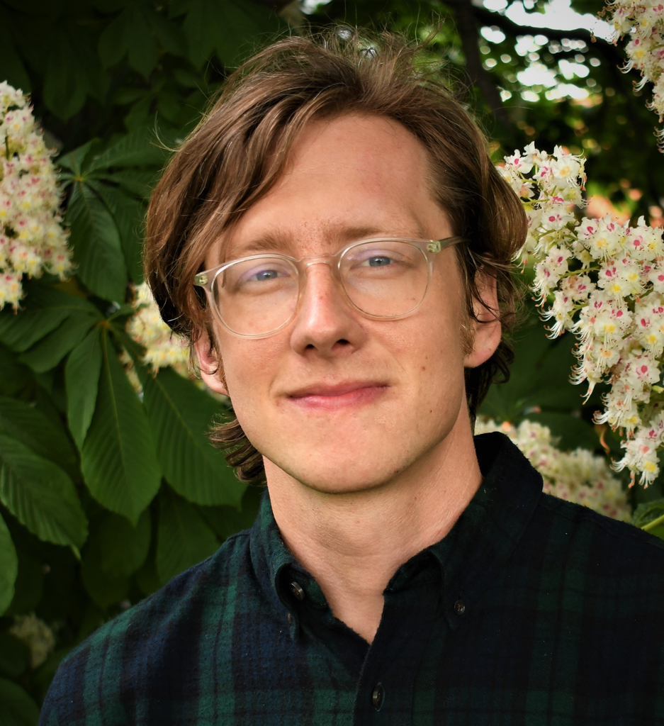

#### About

#### Research

#### Teaching

#### Resources

#### Media

#### Contact

Alex Kowalski is an assistant professor in the Human Resource Studies department at Cornell University’s [ILR School](https://www.ilr.cornell.edu/).

Alex studies how to support good quality jobs in challenging business environments. He currently focuses on the ways managers foist business risk and market uncertainty onto their workforce. He asks why and how managers make this shift, what it means for workers and firm performance, and how the negative consequences can be remedied, with an emphasis on bringing worker voices into the solution.

His research takes place primarily inside e-commerce fulfillment centers, where demand volatility and intense time pressures often give rise to unpredictable work schedules that employees feel to be out of their control. Using a variety of research methods ranging from interviews to field experiments, he shows how certain managerial strategies generate problematic schedules, how these schedules tend to accrue to already disadvantaged employees, and how these schedules are costly to employers.

Fulfillment centers are part of the rapidly evolving warehousing industry. A setting replete with contrasts, warehouses are employing more and more people as e-commerce grows yet are also sites where concerns about job quality are primary and innovation in robotics is proceeding apace. In addition to his focus on scheduling practices, Alex is also carrying out projects inside warehouses that look into the challenges of implementing performance pay systems, competing approaches to robotic automation, and the benefits of involving employees in workplace problem-solving.

By conducting his research out in the field, in actual workplaces, Alex tries to make his findings useful for business practitioners. He brings these insights into the classroom, where he teaches classes on High Road, high performance management and human resource practices, as well as on the ingredients of a good job.

He received his PhD from MIT. He also holds a Master’s in City Planning from UC-Berkeley. Before graduate school, he was an economics reporter for Bloomberg News.

#### Research

##### Published

- Kowalski, A.M., Gutelius, B., Pinto, S., & Vallas, S.P. [At the mercy of the market? E-commerce and warehouse work in the United States](https://journals.sagepub.com/doi/10.1177/00197939261444716). Forthcoming in *ILR Review*. [[Download PDF]](https://ecommons.cornell.edu/entities/publication/9fe7886d-b3dd-4b62-97dc-d0fa7f3cdc7b)

  **Show abstract**

  The growing popularity of e-commerce has made warehouses increasingly vital to retailing. The authors test the proposition that competition for online consumers translates into harsher work conditions inside the warehouses that make e-commerce possible. They use data from three surveys, one providing a national sample of US warehouse workers and two targeting those at Walmart and Amazon, the country’s largest retailers. In the national sample, job quality and worker well-being are lower in warehouses engaged in e-commerce than in traditional warehouses, but this relationship varies across the two firms. The negative effects are most pronounced at Amazon’s e-commerce warehouses, which emphasize speedy delivery. These same effects are less significant at Walmart’s facilities, which aim to offer low prices. Future research should explore whether firms vying for e-commerce business are likely to emulate Amazon, converging on a set of labor practices that diminish work conditions in a growing sector.
- Kowalski, A.M. [Unfulfilled: Collaborative robots and the persistence of tough jobs in e-commerce warehousing](https://doi.org/10.1177/07308884251400283). Forthcoming in *Work and Occupations*. [[Download PDF]](https://hdl.handle.net/1813/118373)

  **Show abstract**

  This paper investigates workers’ experiences with collaborative robots in e-commerce fulfillment centers (FCs). Powered by the latest algorithmic technologies, collaborative robots operate alongside their users rather than independently. There are conflicting accounts of how they will impact job quality. On the one hand, they are dismissed for reducing worker autonomy and permitting more pervasive means of managerial control. On the other, they are heralded for augmenting human capabilities, taking on undesirable tasks, and giving workers more command over their jobs. Yet the actual effects of collaborative robots are underexplored. Using data from a survey of more than 1,500 hourly workers employed in 16 FCs operated by a U.S. retailer, I compare job characteristics and worker attitudes across facilities that use one of three main technologies to retrieve customer orders: collaborative robots, conveyors, or hand-pulled carts. The findings show that, compared to the older technologies, collaborative robots are not associated with significantly better jobs. Relative to workers in cart facilities, workers in robotics facilities report lower levels of job satisfaction, decision authority, skill discretion, and supervisor and coworker support, along with increased job insecurity, turnover intentions, and alienation. These levels are similar to those reported in conveyor facilities. In light of these findings, collaborative robots appear to be a refined means of managerial control rather than a liberating departure from past automating technologies. They are likely to impose burdens on growing numbers of workers as the e-commerce industry expands and as they find their way into other sectors.
- Siebach, K.F., Díaz-Linhart, Y.L., Kubzansky, L.D., Berkman, L., Wang, M., Ge, L., Kowalski, A.M., Rahmandad, H., & Kelly, E.L. (2026). [Effectiveness of a participatory voice intervention on psychological well-being among warehouse workers: Results from the fulfillment center intervention study](https://ajph.aphapublications.org/doi/10.2105/AJPH.2025.308352). *American Journal of Public Health*, 116(4), 522-532. [[Download pre-print PDF]](https://hdl.handle.net/1721.1/164869)

  **Show abstract**

  Objectives. To examine whether a novel workplace intervention designed to increase worker voice can reduce psychological distress and improve emotional vitality at 6- and 12-months follow-up.  
  Methods. We conducted a two-arm cluster-randomized trial (c-RCT) between July 2021 and August 2023 in 16 fulfillment centers (e-commerce warehouses) throughout the United States. Using surveys of non-supervisory employees, we captured psychological distress and emotional vitality at three time points; a total of 2813 workers participated in at least one survey. Fulfillment centers randomized to the intervention arm established a new, participatory committee called the Health and Well-Being Committee (HaWC). We used separate multilevel linear regression models to estimate the effects of the HaWC intervention on psychological distress and emotional vitality. We explore differential treatment effect by gender with a three-way interaction of intervention status, time point and gender.  
  Results. Baseline prevalence of moderate or severe psychological distress across treatment arms was 51%. In the intention-to-treat analyses, workers in intervention sites had lower average psychological distress at the 6-month follow-up (T2) compared to control sites. However, there was no significant intervention effect at 12-month follow-up (T3). Gender moderation analyses suggest the HaWC was particularly effective in reducing psychological distress among men at 6-month follow-up.  
  Conclusions. Our findings suggest that providing opportunities for workers to share their concerns to a committee of their peers who seek to identify solutions can provide mental health benefits, with evidence of intervention benefits at 6-month follow-up. Our study contributes important experimental evidence on workplace interventions that improve the well-being of low-wage U.S. populations.
- Riordan, C. A., & Kowalski, A. M. (2021). [From bread and roses to #MeToo: Multiplicity, distance, and the changing dynamics of conflict in IR theory](https://doi.org/10.1177/0019793920970868). *ILR Review*, 74(3), 580–606.

  **Show abstract**

  A central assumption in industrial relations theory is that conflict is rooted in an enduring difference between the interests of labor and management. In recent years, the reality of work has changed for many, and scholarship has called attention to overlooked dimensions of conflict that depart from this assumption. The authors account for these developments with the concepts of *multiplicity* and *distance*. Multiplicity means that a broad range of actors bring diverse goals, tied to identities and values in addition to interests, to the employment relationship. The competing and fluid motivations that stem from these goals alter how actors individually and collectively name conflict. Distance reflects a growing rift between those who control work and those who labor, rooted in prevailing organizational forms and practices and the transformation of institutions. Distance alters actors’ interdependence and their perceived and actual power in addressing conflict. From these observations, the authors derive propositions suggesting directions for research and theory regarding conflict and the institutions through which actors balance goals.
- Kochan, T. A., Riordan, C. A., Kowalski, A. M., Khan, M., & Yang, D. (2019). [The changing nature of employee and labor-management relationships](https://doi.org/10.1146/annurev-orgpsych-012218-015335). *Annual Review of Organizational Psychology and Organizational Behavior*, 6(1), 195–219.

  **Show abstract**

  This article reviews work and employment research, paying particular attention to theory and applications by scholars in organizational psychology and organizational behavior (OP/OB) and employment or industrial relations (ER), with the objective of better understanding employee and labor-management relationships. Our animating premise is that juxtaposing these two research traditions provides a stronger basis for analyzing these relationships today. OP/OB offer micro- and meso-level focuses, whereas ER focuses on organizations, collective actors, and labor markets, with an emphasis on historical context. We hope this review motivates efforts to think about and build new social and psychological contracts that are attuned to the evolving dynamics present in the economy, workforce, and society. To this end, we look to the future and propose ways of deepening, broadening, and accelerating the pace of research that might lead to useful changes in practices, institutions, and public policies.
- Kochan, T. A., Dyer, L., Cutcher-Gershenfeld, J., & Kowalski, A. M. (2018). [Negotiating a new social contract for work: An online, distributed approach](https://doi.org/10.1111%2Fnejo.12223). *Negotiation Journal*, 34(2), 187–206.

  **Show abstract**

  A massive open online course (MOOC) entitled “Shaping the Future of Work” (offered through MITx, the Massachusetts Institute of Technology’s online learning division) has been the context for a multiparty simulation designed to produce classroom negotiation results that will have social impacts. After running the course in the MOOC context three times and in face‐to‐face settings eight times, we noticed that key themes emerged. Participants have brought their own workforce perspectives to their simulation roles as employers, worker representatives, elected officials, and educators. They have called for reciprocal agreements centered on fair treatment and representation in the workplace, improved organizational performance, investments in skills and capabilities, aligned rewards and benefits for workers, and work–life balance in communities. We continue to use the simulation in the classroom and are exploring ways to expand its use. In the meantime, in this article, we discuss how the insights gleaned from this simulation could be used to crystallize and advance a new social contract at a time when the public policies, institutions, and organizational practices governing employment relations have not kept up with the dramatic changes taking place in the workforce, nature of work, and overall economy.

##### Work in progress

- Kowalski, A.M., Kelly, E.L., Rahmandad, H., & Siebach, K. F. [Can a voice channel reduce turnover? Evidence on employee voice and exit from a cluster-randomized trial in U.S. fulfillment centers.](http://ssrn.com/abstract=5193024)

  **Show abstract**

  Building on the long research tradition on employee voice and its impact on both employees and organizations, we investigate whether a new voice channel reduces job exit in e-commerce fulfillment centers. A cluster-randomized trial compared hourly workers in sites randomized to launch the voice channel (Health and Well-Being Committees, or HaWCs) with those employed by the same U.S. firm in control sites. This participatory intervention involved a small group of frontline workers and supervisors who solicited concerns and ideas about workplace stressors, work processes, and safety from the broader workforce and then developed and implemented improvement projects in response. HaWCs were an isolated change, rather than one component of a high-involvement work system, and they were implemented in non-union workplaces, raising questions about their likely impact. An intention-to-treat analysis finds individual workers’ monthly probability of exit fell by 1.3%-points in HaWC sites in the year after randomization, representing a 19.7% decline relative to pre-intervention exit rates. Two secondary analyses show that exit risk is significantly lower for workers in sites where more workplace improvements are made and among individuals who attribute more improvements to the HaWCs. Our findings demonstrate the feasibility of addressing turnover and improving the work environment with employee voice, even in tough conditions like fulfillment centers. They also highlight the ways in which the opportunity to voice and the impact voice has on work conditions are holistically related to turnover while underscoring the importance of separating voice channels from supporting structures and practices when estimating voice effects.
- Kowalski, A.M. How to squeeze the lemon: Local organizational cultures and varied management practices.
- Kowalski, A.M. and Kelly, E.L. The toll of toil: The turnover costs of problematic work schedules.

#### Teaching

Alex has developed two courses at Cornell. The first, *People and Profits: HR Strategies for Good Jobs*, is a class aimed at undergraduates and master’s students that reviews the best practices that businesses are using to treat their employees well while remaining competitive. The second, *Building Better Jobs*, is an undergraduate seminar that draws on ethnographies of work to figure out what it would mean to have a high quality job in the age of automation. More details below.

- **ILRHR 4645/6645** *People and Profits: HR Strategies for Good Jobs*

  **Show course details**

  Economic, social, technological, and political upheaval are transforming the workplace. What role do managers and HR professionals have in shaping how these transformations play out? In this course, we will debate whether, in responding to these challenges, those who manage people must choose between running a profitable business and treating their employees well. To arrive at an answer, we will begin by identifying the most pressing HR issues inside organizations today, ranging from burnout and scheduling inflexibility to earnings inequality and limited career mobility. Next, we will develop a framework for assessing and promoting high quality jobs. We will then use case studies, cutting-edge research, and conversations with business professionals and workers to explore how certain organizations are able to provide good jobs while remaining competitive. Throughout our exploration, we will have realistic conversations about how difficult it can be to drive positive change. At the end of the course, students will be asked to put forth their own ideas for balancing people and profits.
- **ILRHR 2685** *Building Better Jobs*

  **Show course details**

  This seminar explores the dirty, dull, and dangerous jobs that many science and technology experts believe can and should be replaced by robots, algorithms, artificial intelligence, and other recent innovations. Rather than accept that certain jobs are inherently bad, we will critically examine what can make even the toughest work rewarding and the most prestigious career unfulfilling. We will use our insights to sketch out the key determinants of a good quality job and then learn about evidence-based policies and practices that organizations can use to evaluate and improve the jobs they offer.

#### Resources

Here are select materials, based on Alex’s research, for those who work in and manage organizations.

- Want to promote employee voice at your organization and reap the benefits that follow? Here are detailed resources on launching your own version of the voice initiative Alex has studied in warehouses, which improved employee retention and well-being:
  - [Starting a workplace Health and Well-Being Committee: A step-by-step guide for managers](https://mitsloan.mit.edu/centers-initiatives/institute-work-and-employment-research/starting-a-workplace-health-and-well-being-committee-a-step-step-guide-managers) Institute for Work & Employment Research, MIT Sloan. (July 18, 2025).
- What makes for an ideal work schedule, and how can you offer one? Check out this comprehensive review of research on scheduling best practices:
  - [Craft schedules that work for everyone](https://sloanreview.mit.edu/article/craft-schedules-that-work-for-everyone/). Coauthored with D. Sull. *Sloan Management Review* (Dec. 10, 2024).

*A note to practitioners*: A key component of my work is going inside workplaces to speak with workers and managers, those who know the challenges best and who also often have the best idea for how to fix things. Do you run, work for, or know a company that wants to offer better jobs or that should be highlighted for already offering them? Reach out and tell me about it.

#### Media

- [The real cost of fast-delivered packages](https://podcasts.apple.com/us/podcast/the-real-cost-of-fast-delivered-packages/id1168275879?i=1000771309625). (June 6, 2026). *The Last Show with David Cooper*.
- [Fast deliveries worsen conditions for e-commerce warehouse workers](https://news.cornell.edu/stories/2026/05/fast-deliveries-worsen-conditions-e-commerce-warehouse-workers). Dean, J (May 19, 2026). *Cornell Chronicle*.
- [Spotlight: An interview with Alexander Kowalski](https://www.asanet.org/wp-content/uploads/2025/05/Economic-Sociology-2025-Spring.pdf) [PDF]. (Spring 2025). *Accounts*, the ASA Economic Sociology newsletter.
- [As the warehouse industry cools, will workers lose their leverage?](https://bizeconreporting.journalism.cuny.edu/2024/05/24/as-the-warehouse-industry-cools-will-workers-lose-their-leverage/) Burke, L (May 24, 2024). *The Invisible Hand*.
- [Amazon built the retail of today — its robots are building the Amazon of tomorrow](https://finance.yahoo.com/news/amazon-built-the-retail-of-today--its-robots-are-building-the-amazon-of-tomorrow-150249496.html). Garfinkle, A (Nov. 13, 2023). *Yahoo Finance*.
- [How mobile robots are redefining employment and efficiency](https://www.shrm.org/topics-tools/news/all-things-work/mobile-robots-work). Harbert, T (March 31, 2023). *All Things Work*.
- [How the warehouse boom devoured America’s workforce](https://www.businessinsider.com/warehouse-jobs-economy-impact-blue-collar-pay-employment-hiring-boom-2022-10). Ito, A (Oct. 19, 2022). *Business Insider*.

#### Contact

You can reach me at alex**.email**.kowalski [at] cornell.edu.

###### Top ↺